# 時系列分析 第 8 回 分析例

VAR (MSCI)

Kenichiro Tamaki

2022 年 5 月 30 日

# 1 パッケージ

必要なパッケージは次である.

```r
library(readxl) # xls ファイルの読込
library(quantmod) # 時系列データに変換
library(vars) # VAR
```

# 2 関数の作成

自作関数は次である.

**VAR の残差に対するかばん検定**

```r
port.v <- function(x, lag) { # x = 推定結果, lag = ラグ
  res <- serial.test(x, lags.pt = lag, type = "PT.adjusted") # かばん検定
  res <- c(lag, res$serial$statistic, res$serial$parameter, res$serial$p.value) # ラグ, 検定統計量, 自由度, p 値

  return(res)
}
```

# 3 データの概要

## 3.1 データの入手と編集

MSCI が提供している株式指数を用いる.

- https://www.msci.com/

上記の「Solutions」→「Indexes」→「PERFORMANCE 」→「End of Day Index Data Search」から, 様々なデータ (xls ファイル) をダウンロードできる.

ここでは, 次のデータを用いる.

- 2012年1月から2015年12月までの4年間の日次株式指数
- 日本, イギリス, アメリカの3カ国

ファイル名をそれぞれ「JP.xls」,「UK.xls」, 「US.xls」とする. 必要ない箇所を削除し, さらに, 文字列形式であるから Excel か R で変換する必要がある. ファイルは, 1列目は日付, 2列目は数値に変換済とする.

RStudio の右上にある「Environment」→「Import Dateset」→「From Excel..」において, xls ファイルの読込が出来る. または, 次を実行する.

```r
JP <- read_excel("JP.xls") # 日本
UK <- read_excel("UK.xls") # イギリス
US <- read_excel("US.xls") # アメリカ
```

時系列に変換する.

```r
JP <- as.xts(read.zoo(JP)) # 日本
UK <- as.xts(read.zoo(UK)) # イギリス
US <- as.xts(read.zoo(US)) # アメリカ
```

標本数は次である.

```r
(T <- length(JP)) # 標本数
```

```
## [1] 1044
```

日付情報が同じであるか確認する.

```r
sum(index(JP) != index(UK)) # 日本とイギリスの日付情報が異なる数
```

```
## [1] 0
```

```r
sum(index(JP) != index(US)) # 日本とアメリカの日付情報が異なる数
```

```
## [1] 0
```

欠損値の有無を確認する.

```r
MSCI <- cbind(JP, UK, US) # データを結合
sum(is.na(MSCI)) # 欠損値の数
```

```
## [1] 0
```

データの中身を確認する.

```r
head(MSCI, 5) # 最初の 5 個を表示
```

```
##                  JP       UK       US
## 2012-01-02 2091.151 1068.187 1199.646
## 2012-01-03 2096.328 1099.035 1218.118
## 2012-01-04 2138.031 1091.311 1218.439
## 2012-01-05 2107.949 1073.754 1222.439
## 2012-01-06 2088.331 1073.907 1219.596
```

```r
tail(MSCI, 5) # 最後の 5 個を表示
```

```
##                  JP       UK       US
## 2015-12-25 2758.608 1134.930 1965.393
## 2015-12-28 2779.230 1131.892 1961.149
## 2015-12-29 2798.239 1134.164 1981.712
## 2015-12-30 2801.883 1129.676 1967.520
## 2015-12-31 2808.288 1116.723 1949.703
```

## 3.2 時系列プロット, 記述統計量, コレログラム

**株式指数**

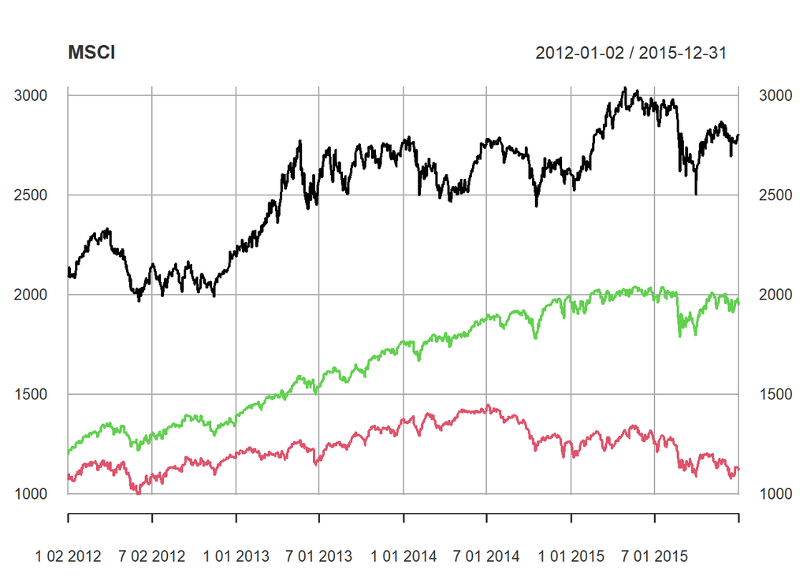

```r
plot(MSCI) # 時系列プロット
```

```r
summary(coredata(MSCI)) # 記述統計量
```

```
##        JP             UK               US
##  Min.   :1965   Min.   : 996.3   Min.   :1200
##  1st Qu.:2281   1st Qu.:1158.0   1st Qu.:1394
##  Median :2625   Median :1239.0   Median :1726
##  Mean   :2542   Mean   :1238.4   Mean   :1676
##  3rd Qu.:2743   3rd Qu.:1311.2   3rd Qu.:1921
##  Max.   :3044   Max.   :1447.3   Max.   :2042
```

```r
cov(coredata(MSCI)) # 共分散行列
```

```
##          JP        UK       US
## JP 79483.29 17946.017 67219.85
## UK 17946.02  9786.019 16212.17
## US 67219.85 16212.169 69313.25
```

```r
cor(coredata(MSCI)) # 相関行列
```

```
##           JP        UK        US
## JP 1.0000000 0.6434683 0.9056314
## UK 0.6434683 1.0000000 0.6224865
## US 0.9056314 0.6224865 1.0000000
```

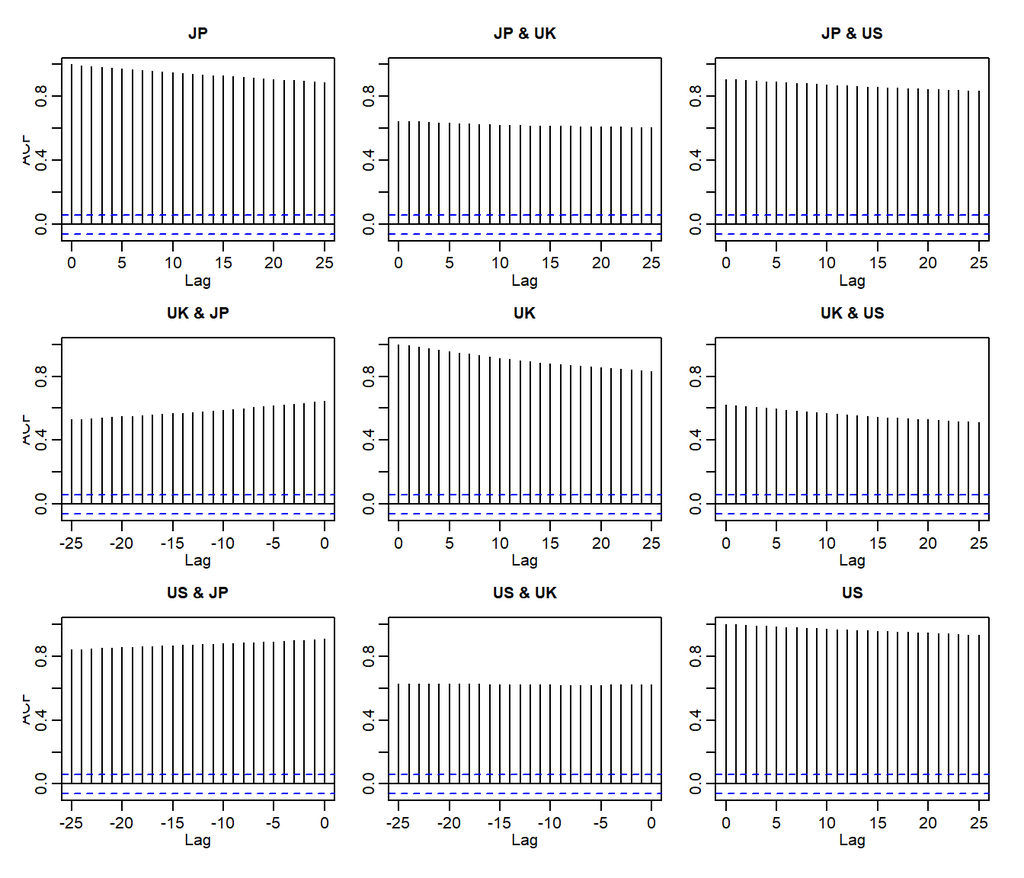

```r
acf(coredata(MSCI)) # コレログラム
```

**対数収益率**

対数収益率 (%) に変換する.

```r
JP.r <- dailyReturn(MSCI$JP, type = 'log') * 100 # 日本
UK.r <- dailyReturn(MSCI$UK, type = 'log') * 100 # イギリス
US.r <- dailyReturn(MSCI$US, type = 'log') * 100 # アメリカ
MSCI.r <- cbind(JP.r, UK.r, US.r) # データを結合
names(MSCI.r) <- names(MSCI) # 名称を変更
```

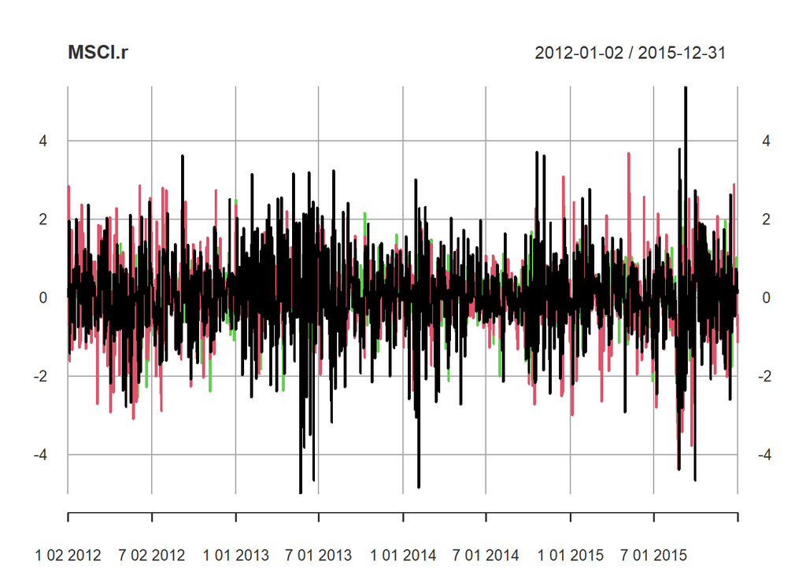

```r
plot(MSCI.r) # 時系列プロット
```

```r
summary(coredata(MSCI.r)) # 記述統計量
```

```
##        JP                  UK                  US
##  Min.   :-4.990809   Min.   :-4.356830   Min.   :-4.04436
##  1st Qu.:-0.617304   1st Qu.:-0.511620   1st Qu.:-0.34180
##  Median : 0.007382   Median : 0.003208   Median : 0.02835
##  Mean   : 0.028243   Mean   : 0.004256   Mean   : 0.04652
##  3rd Qu.: 0.681691   3rd Qu.: 0.544304   3rd Qu.: 0.48493
##  Max.   : 5.380266   Max.   : 3.701334   Max.   : 3.76920
```

```r
cov(coredata(MSCI.r)) # 共分散行列
```

```
##            JP        UK         US
## JP 1.30281075 0.1954238 0.04804827
## UK 0.19542376 0.9588444 0.43876423
## US 0.04804827 0.4387642 0.62712281
```

```r
cor(coredata(MSCI.r)) # 相関行列
```

```
##            JP        UK         US
## JP 1.00000000 0.1748488 0.05315703
## UK 0.17484879 1.0000000 0.56582332
## US 0.05315703 0.5658233 1.00000000
```

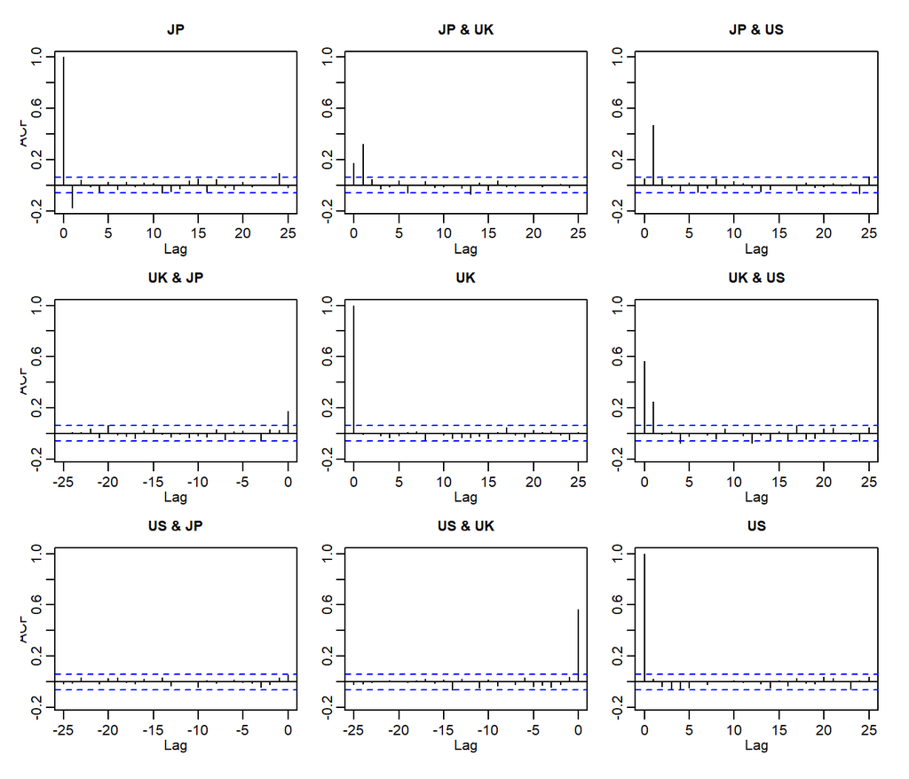

```r
acf(coredata(MSCI.r)) # コレログラム
```

# 4 推定

パッケージ vars を用いて分析を行う.

## 4.1 次数の決定

情報量基準を用いて, VAR モデルの次数を決定する.

```r
(IC <- VARselect(MSCI.r)) # 情報量基準
```

```
## $selection
## AIC(n)  HQ(n)  SC(n) FPE(n)
##      2      2      1      2
##
## $criteria
##                 1          2          3          4          5          6
## AIC(n) -1.0896161 -1.1242056 -1.1206054 -1.1087896 -1.1072496 -1.0942333
## HQ(n)  -1.0678565 -1.0861264 -1.0662066 -1.0380711 -1.0202115 -0.9908755
## SC(n)  -1.0322715 -1.0238526 -0.9772440 -0.9224197 -0.8778714 -0.8218466
## FPE(n)  0.3363456  0.3249107  0.3260829  0.3299594  0.3304691  0.3348004
##                 7          8          9         10
## AIC(n) -1.0858345 -1.0784322 -1.0665262 -1.0540138
## HQ(n)  -0.9661571 -0.9424351 -0.9142095 -0.8853774
## SC(n)  -0.7704394 -0.7200287 -0.6651142 -0.6095934
## FPE(n)  0.3376264  0.3401380  0.3442158  0.3485548
```

AIC では VAR(2), BIC では VAR(1) が選択される.

## 4.2 パラメータの推定

AIC と BIC で結果が異なるので, 両方用いて推定を行う.

```r
M1 <- VAR(MSCI.r, lag.max = 10, ic = "AIC") # AIC によるモデルの推定
M2 <- VAR(MSCI.r, lag.max = 10, ic = "SC") # BIC によるモデルの推定
```

AIC により推定される VAR(2) を Model 1, BIC により推定される VAR(1) を Model 2 とする.

推定結果を表示する. Model 1 の結果は量が多いので, Model 2 の結果を表示する.

```r
summary(M2) # Model 2 の推定結果を表示
```

```
##
## VAR Estimation Results:
## =========================
## Endogenous variables: JP, UK, US
## Deterministic variables: const
## Sample size: 1043
## Log Likelihood: -3861.167
## Roots of the characteristic polynomial:
## 0.2981 0.2382 0.0922
## Call:
## VAR(y = MSCI.r, lag.max = 10, ic = "SC")
##
##
## Estimation results for equation JP:
## ===================================
## JP = JP.l1 + UK.l1 + US.l1 + const
##
##        Estimate Std. Error t value Pr(>|t|)
## JP.l1 -0.219384   0.026928  -8.147 1.06e-15 ***
## UK.l1  0.149588   0.038020   3.934 8.89e-05 ***
## US.l1  0.590432   0.046353  12.738  < 2e-16 ***
## const  0.005615   0.030296   0.185    0.853
## ---
## Signif. codes:  0 '***' 0.001 '**' 0.01 '*' 0.05 '.' 0.1 ' ' 1
##
##
## Residual standard error: 0.9757 on 1039 degrees of freedom
## Multiple R-Squared: 0.272,   Adjusted R-squared: 0.2699
## F-statistic: 129.4 on 3 and 1039 DF,  p-value: < 2.2e-16
##
##
## Estimation results for equation UK:
## ===================================
## UK = JP.l1 + UK.l1 + US.l1 + const
##
##       Estimate Std. Error t value Pr(>|t|)
## JP.l1  0.04139    0.02576   1.607    0.108
## UK.l1 -0.22475    0.03637  -6.180 9.22e-10 ***
## US.l1  0.46055    0.04434  10.387  < 2e-16 ***
## const -0.01754    0.02898  -0.605    0.545
```

[output cut: 24 more lines]

```
## F-statistic: 0.6349 on 3 and 1039 DF,  p-value: 0.5926
##
##
##
## Covariance matrix of residuals:
##         JP      UK      US
## JP 0.95204 0.09027 0.04286
## UK 0.09027 0.87117 0.44006
## US 0.04286 0.44006 0.62838
##
## Correlation matrix of residuals:
##         JP      UK      US
## JP 1.00000 0.09912 0.05541
## UK 0.09912 1.00000 0.59477
## US 0.05541 0.59477 1.00000
```

**Model 2**

$$\begin{align}
\begin{pmatrix}
\text{JP}_{t} \\
\text{UK}_{t} \\
\text{US}_{t}
\end{pmatrix}
=
\begin{pmatrix}
0.00561 \\
-0.0175 \\
0.046
\end{pmatrix}
+
\begin{pmatrix}
-0.219 & 0.15 & 0.59 \\
0.0414 & -0.225 & 0.461 \\
0.0166 & 0.0255 & -6.37\times 10^{-6}
\end{pmatrix}
\begin{pmatrix}
\text{JP}_{t - 1} \\
\text{UK}_{t - 1} \\
\text{US}_{t - 1}
\end{pmatrix}
+
\begin{pmatrix}
\varepsilon_{1, t} \\
\varepsilon_{2, t} \\
\varepsilon_{3, t}
\end{pmatrix}
\end{align}$$

**Model 1**

$$\begin{align}
\begin{pmatrix}
\text{JP}_{t} \\
\text{UK}_{t} \\
\text{US}_{t}
\end{pmatrix}
&=
\begin{pmatrix}
-8.61\times 10^{-4} \\
-0.0252 \\
0.0483
\end{pmatrix}
+
\begin{pmatrix}
-0.306 & 0.124 & 0.61 \\
0.0459 & -0.249 & 0.478 \\
0.0363 & 0.0427 & -0.0121
\end{pmatrix}
\begin{pmatrix}
\text{JP}_{t - 1} \\
\text{UK}_{t - 1} \\
\text{US}_{t - 1}
\end{pmatrix} \\
& \hspace{8em} +
\begin{pmatrix}
-0.0487 & 0.0803 & 0.182 \\
0.0376 & -0.0655 & 0.0712 \\
-0.00625 & 0.00826 & -0.0771
\end{pmatrix}
\begin{pmatrix}
\text{JP}_{t - 2} \\
\text{UK}_{t - 2} \\
\text{US}_{t - 2}
\end{pmatrix}
+
\begin{pmatrix}
\varepsilon_{1, t} \\
\varepsilon_{2, t} \\
\varepsilon_{3, t}
\end{pmatrix}
\end{align}$$

## 4.3 モデル診断

残差の自己相関を調べ, モデルが妥当かどうかを診断する. まず, コレログラムをプロットする.

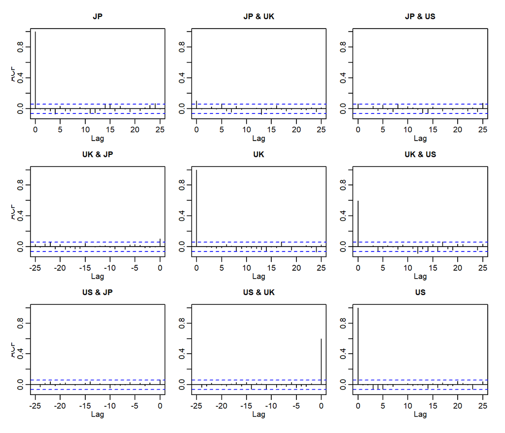

```r
acf(residuals(M1)) # Model 1 の残差のコレログラム
```

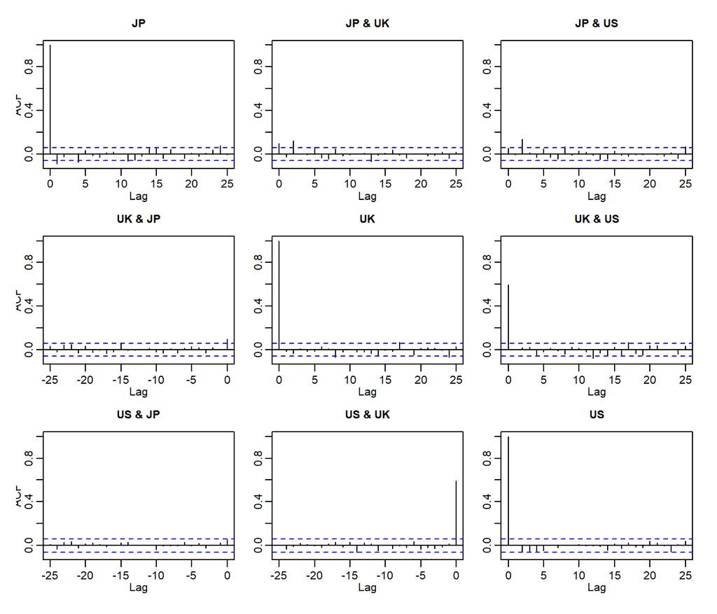

```r
acf(residuals(M2)) # Model 2 の残差のコレログラム
```

次に, かばん検定を行う.

```r
m <- 10 # 最大ラグ
lag <- 1:m + IC$selection[1] # ラグ (1, ..., m) + p
res.port1 <- sapply(lag, port.v, x = M1) # x に対して各 lag の port.v を計算

digits <- c(0, 2, 0, 4) # 少数点以下の最大表示桁数
col.names <- c("$m$", "$Q(m)$", "自由度", "$p$ 値") # 列名
# 表を作成
knitr::kable(t(res.port1), # 転置
             digits = digits, # 少数点以下の最大表示桁数
             col.names = col.names, # 列名
             caption = "Model 1 の残差に対するかばん検定", # 表題
             format.args = list(scientific = FALSE)) # 指数表記をしない
```

Model 1 の残差に対するかばん検定

| $m$ | $Q(m)$ | 自由度 | $p$ 値 |
| --- | --- | --- | --- |
| 3 | 14.43 | 9 | 0.1079 |
| 4 | 25.67 | 18 | 0.1075 |
| 5 | 35.71 | 27 | 0.1218 |
| 6 | 40.93 | 36 | 0.2629 |
| 7 | 47.15 | 45 | 0.3845 |
| 8 | 58.98 | 54 | 0.2985 |
| 9 | 64.28 | 63 | 0.4315 |
| 10 | 68.46 | 72 | 0.5965 |
| 11 | 78.18 | 81 | 0.5682 |
| 12 | 95.27 | 90 | 0.3318 |

全てにおいて $p$ 値が $0.05$ より大きいので, 有意水準 $5 \%$ で帰無仮説を棄却できない. つまり, 残差に自己相関があると判断できないので, Model 1 は妥当である．

```r
m <- 10 # 最大ラグ
lag <- 1:m + IC$selection[3] # ラグ (1, ..., m) + p
res.port2 <- sapply(lag, port.v, x = M2) # x に対して各 lag の port.v を計算

# 表を作成
knitr::kable(t(res.port2), # 転置
             digits = digits, # 少数点以下の最大表示桁数
             col.names = col.names, # 列名
             caption = "Model 2 の残差に対するかばん検定", # 表題
             format.args = list(scientific = FALSE)) # 指数表記をしない
```

Model 2 の残差に対するかばん検定

| $m$ | $Q(m)$ | 自由度 | $p$ 値 |
| --- | --- | --- | --- |
| 2 | 51.29 | 9 | 0.0000 |
| 3 | 60.28 | 18 | 0.0000 |
| 4 | 72.15 | 27 | 0.0000 |
| 5 | 81.39 | 36 | 0.0000 |
| 6 | 86.27 | 45 | 0.0002 |
| 7 | 92.32 | 54 | 0.0009 |
| 8 | 105.75 | 63 | 0.0006 |
| 9 | 110.93 | 72 | 0.0022 |
| 10 | 114.65 | 81 | 0.0083 |
| 11 | 124.82 | 90 | 0.0089 |

全てにおいて $p$ 値が $0.05$ より小さいので, 有意水準 $5 \%$ で帰無仮説を棄却する．つまり, 残差に自己相関があると判断できるので, Model 2 は適切でない．

# 5 分析

モデル診断の結果より, Model 1 を用いて分析を行う.

## 5.1 グレンジャー因果性

グレンジャー因果性の検定を行う.

```r
causality(M1, cause = "JP") # JP → UK, US
```

```
## $Granger
##
##  Granger causality H0: JP do not Granger-cause UK US
##
## data:  VAR object M1
## F-Test = 1.6341, df1 = 4, df2 = 3105, p-value = 0.1628
##
##
## $Instant
##
##  H0: No instantaneous causality between: JP and UK US
##
## data:  VAR object M1
## Chi-squared = 10.683, df = 2, p-value = 0.004788
```

これは, 1つの変数の他の全ての変数に対する検定であり, 他の1つの変数に対する検定ではない. 関数 causality では, 他の1つの変数に対する検定を行うには $2$ 変量 VAR モデルを用いなければならない.

### 5.1.1 日本とイギリス

```r
JPUK <- cbind(MSCI.r$JP, MSCI.r$UK) # 日本とイギリスの標本
M1.jpuk <- VAR(JPUK, lag.max = 10, ic = "AIC") # AIC によるモデルの推定
M1.jpuk$p # VAR 次数
```

```
## AIC(n)
##      2
```

```r
serial.test(M1.jpuk, lags.pt = M1.jpuk$p + 1, type = "PT.adjusted") # かばん検定
```

```
##
##  Portmanteau Test (adjusted)
##
## data:  Residuals of VAR object M1.jpuk
## Chi-squared = 4.7375, df = 4, p-value = 0.3153
```

かばん検定の $p$ 値が $0.05$ より大きいので, 有意水準 $5 \%$ で帰無仮説を棄却できない. つまり, 残差に自己相関があると判断できないので, モデルは妥当である.

```r
causality(M1.jpuk, cause = "JP") # JP → UK
```

```
## $Granger
##
##  Granger causality H0: JP do not Granger-cause UK
##
## data:  VAR object M1.jpuk
## F-Test = 1.2442, df1 = 2, df2 = 2074, p-value = 0.2884
##
##
## $Instant
##
##  H0: No instantaneous causality between: JP and UK
##
## data:  VAR object M1.jpuk
## Chi-squared = 42.359, df = 1, p-value = 7.597e-11
```

$p$ 値が $0.05$ より大きいので, 有意水準 $5 \%$ で帰無仮説を棄却できない．つまり, 日本からイギリスへのグレンジャー因果性は存在すると判断できない．

```r
causality(M1.jpuk, cause = "UK") # UK → JP
```

```
## $Granger
##
##  Granger causality H0: UK do not Granger-cause JP
##
## data:  VAR object M1.jpuk
## F-Test = 93.372, df1 = 2, df2 = 2074, p-value < 2.2e-16
##
##
## $Instant
##
##  H0: No instantaneous causality between: UK and JP
##
## data:  VAR object M1.jpuk
## Chi-squared = 42.359, df = 1, p-value = 7.597e-11
```

$p$ 値が $0.05$ より小さいので, 有意水準 $5 \%$ で帰無仮説を棄却できる．つまり, イギリスから日本へのグレンジャー因果性は存在すると判断できる．

### 5.1.2 日本とアメリカ

```r
JPUS <- cbind(MSCI.r$JP, MSCI.r$US) # 日本とアメリカの標本
M1.jpus <- VAR(JPUS, lag.max =10, ic = "AIC") # AIC によるモデルの推定
M1.jpus$p # VAR 次数
```

```
## AIC(n)
##      2
```

```r
serial.test(M1.jpus, lags.pt = M1.jpus$p + 1, type = "PT.adjusted") # かばん検定
```

```
##
##  Portmanteau Test (adjusted)
##
## data:  Residuals of VAR object M1.jpus
## Chi-squared = 7.6123, df = 4, p-value = 0.1069
```

かばん検定の $p$ 値が $0.05$ より大きいので, 有意水準 $5 \%$ で帰無仮説を棄却できない. つまり, 残差に自己相関があると判断できないので, モデルは妥当である.

```r
causality(M1.jpus, cause = "JP") # JP → US
```

```
## $Granger
##
##  Granger causality H0: JP do not Granger-cause US
##
## data:  VAR object M1.jpus
## F-Test = 1.3722, df1 = 2, df2 = 2074, p-value = 0.2538
##
##
## $Instant
##
##  H0: No instantaneous causality between: JP and US
##
## data:  VAR object M1.jpus
## Chi-squared = 4.898, df = 1, p-value = 0.02689
```

$p$ 値が $0.05$ より大きいので, 有意水準 $5 \%$ で帰無仮説を棄却できない．つまり, 日本からアメリカへのグレンジャー因果性は存在すると判断できない．

```r
causality(M1.jpus, cause = "US") # US → JP
```

```
## $Granger
##
##  Granger causality H0: US do not Granger-cause JP
##
## data:  VAR object M1.jpus
## F-Test = 186.32, df1 = 2, df2 = 2074, p-value < 2.2e-16
##
##
## $Instant
##
##  H0: No instantaneous causality between: US and JP
##
## data:  VAR object M1.jpus
## Chi-squared = 4.898, df = 1, p-value = 0.02689
```

$p$ 値が $0.05$ より小さいので, 有意水準 $5 \%$ で帰無仮説を棄却できる．つまり, アメリカから日本へのグレンジャー因果性は存在すると判断できる．

### 5.1.3 イギリスとアメリカ

```r
UKUS <- cbind(MSCI.r$UK, MSCI.r$US) # イギリスとアメリカの標本
M1.ukus <- VAR(UKUS, lag.max =10, ic = "AIC") # AIC によるモデルの推定
M1.ukus$p # VAR 次数
```

```
## AIC(n)
##      3
```

```r
serial.test(M1.ukus, lags.pt = M1.ukus$p + 1, type = "PT.adjusted") # かばん検定
```

```
##
##  Portmanteau Test (adjusted)
##
## data:  Residuals of VAR object M1.ukus
## Chi-squared = 5.2748, df = 4, p-value = 0.2602
```

かばん検定の $p$ 値が $0.05$ より大きいので, 有意水準 $5 \%$ で帰無仮説を棄却できない. つまり, 残差に自己相関があると判断できないので, モデルは妥当である.

```r
causality(M1.ukus, cause = "UK") # UK → US
```

```
## $Granger
##
##  Granger causality H0: UK do not Granger-cause US
##
## data:  VAR object M1.ukus
## F-Test = 0.90654, df1 = 3, df2 = 2068, p-value = 0.4371
##
##
## $Instant
##
##  H0: No instantaneous causality between: UK and US
##
## data:  VAR object M1.ukus
## Chi-squared = 276.57, df = 1, p-value < 2.2e-16
```

$p$ 値が $0.05$ より大きいので, 有意水準 $5 \%$ で帰無仮説を棄却できない．つまり, イギリスからアメリカへのグレンジャー因果性は存在すると判断できない．

```r
causality(M1.ukus, cause = "US") # US → UK
```

```
## $Granger
##
##  Granger causality H0: US do not Granger-cause UK
##
## data:  VAR object M1.ukus
## F-Test = 38.165, df1 = 3, df2 = 2068, p-value < 2.2e-16
##
##
## $Instant
##
##  H0: No instantaneous causality between: US and UK
##
## data:  VAR object M1.ukus
## Chi-squared = 276.57, df = 1, p-value < 2.2e-16
```

$p$ 値が $0.05$ より小さいので, 有意水準 $5 \%$ で帰無仮説を棄却できる．つまり, アメリカからイギリスへのグレンジャー因果性は存在すると判断できる

## 5.2 インパルス応答関数

$1$ 標準偏差のショックを与えたときの直交化 IRF を計算しプロットする.

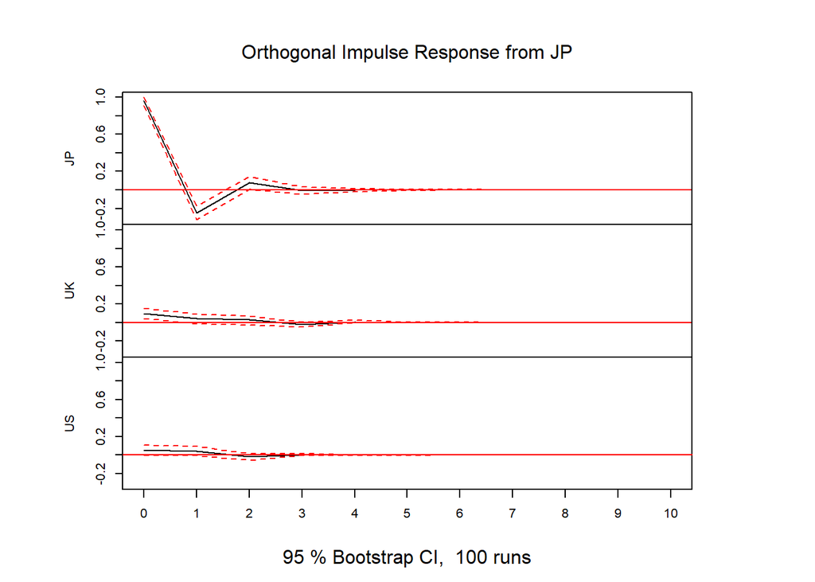

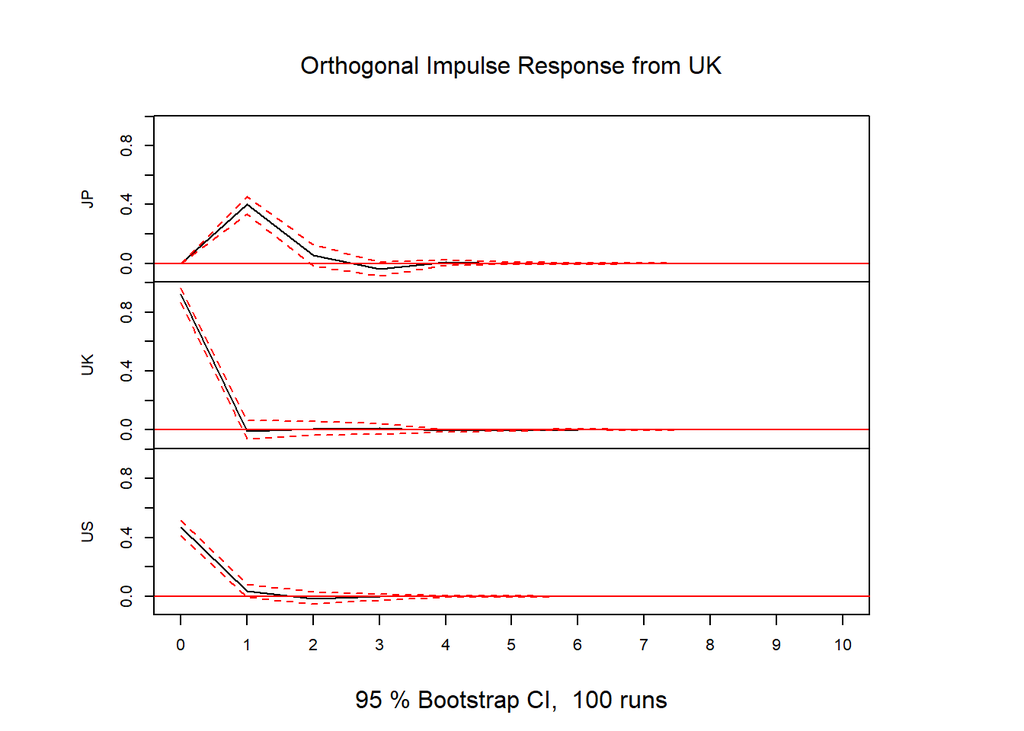

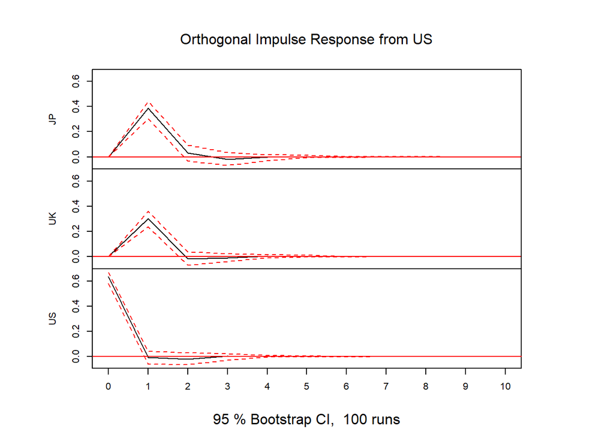

```r
M1.irf <- irf(M1) # IRF
plot(M1.irf) # IRF をプロット
```

```r
M1.irf$irf # IRF を表示
```

```
## $JP
##                  JP            UK            US
##  [1,]  9.622788e-01  9.437772e-02  5.171381e-02
##  [2,] -2.514866e-01  4.533771e-02  3.833272e-02
##  [3,]  7.622256e-02  2.914774e-02 -1.688779e-02
##  [4,] -7.179723e-03 -2.152872e-02  3.206278e-03
##  [5,] -2.960343e-03  6.323930e-03 -1.517774e-04
##  [6,]  8.040864e-04 -4.169070e-04 -2.158860e-04
##  [7,]  1.941882e-04 -4.984930e-04  9.645711e-05
##  [8,] -1.743556e-04  2.214256e-04 -7.218545e-06
##  [9,]  4.457832e-05 -1.984153e-05 -9.561469e-06
## [10,]  2.989382e-06 -1.914348e-05  4.363102e-06
## [11,] -6.130645e-06  9.288412e-06 -4.666751e-07
##
## $UK
```

[output cut: 26 more lines]

上記より, 日本市場における予想外の $0.962 \%$ の変動は, 1日後の日本市場に $-0.251 \%$, 同日のイギリス市場に $0.0944 \%$, 同日のアメリカ市場に $0.0517 \%$ の影響を与える.

イギリス市場における予想外の $0.924 \%$ の変動は, 1日後の日本市場に $0.402 \%$, 同日のアメリカ場に $0.47 \%$ の影響を与える.

アメリカ市場における予想外の $0.634 \%$ 変動, 1日後の日本市場に $0.387 \%$, 1日後のイギリス市場に $0.303 \%$ の影響を与える.

全ての場合において, 2日後以降は大きな影響はない.

## 5.3 分散分解

RVC を計算しプロットする.

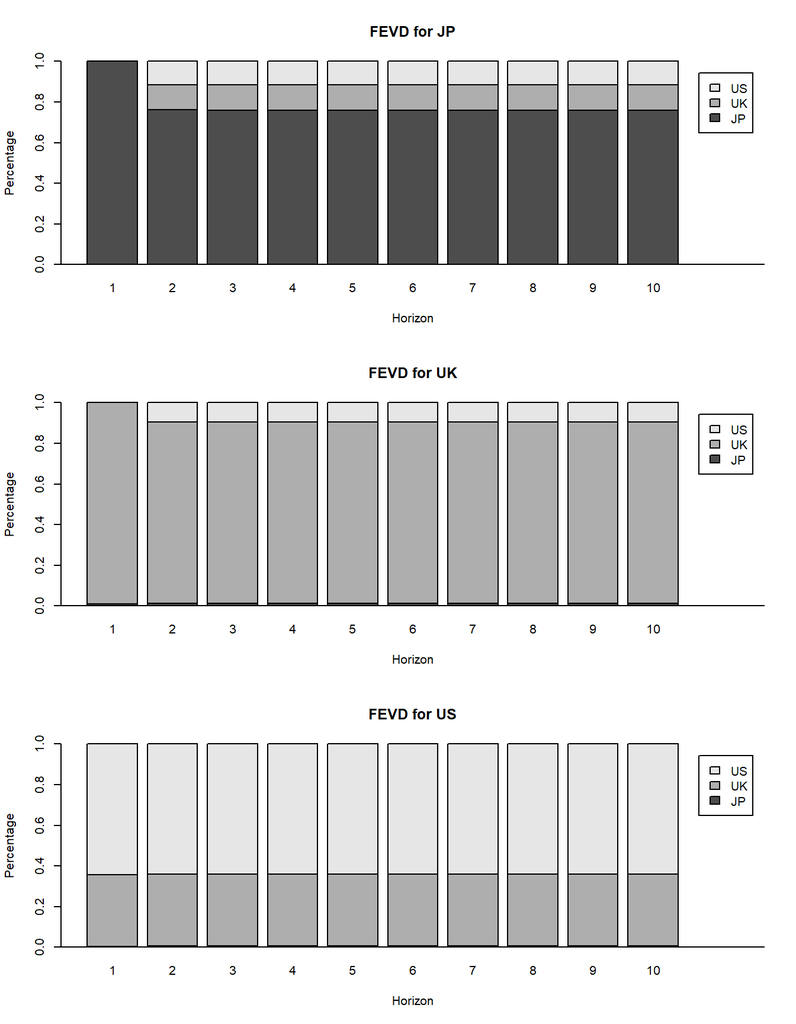

```r
M1.rvc <- fevd(M1) # RVC, forecast error variance decomposition
plot(M1.rvc) # RVC をプロット
```

```r
M1.rvc # RVC を表示
```

```
## $JP
##              JP        UK        US
##  [1,] 1.0000000 0.0000000 0.0000000
##  [2,] 0.7607324 0.1239782 0.1152894
##  [3,] 0.7594105 0.1254921 0.1150974
##  [4,] 0.7582939 0.1264658 0.1152402
##  [5,] 0.7582658 0.1264984 0.1152357
##  [6,] 0.7582650 0.1264984 0.1152365
##  [7,] 0.7582650 0.1264985 0.1152365
##  [8,] 0.7582649 0.1264985 0.1152365
##  [9,] 0.7582649 0.1264985 0.1152365
## [10,] 0.7582649 0.1264985 0.1152365
##
## $UK
##               JP        UK         US
```

[output cut: 23 more lines]

上記より, 長期的には, 日本市場の予測できない変動は, 日本市場が $75.8 \%$, イギリス市場が $12.6 \%$, アメリカ市場が $11.5 \%$ の説明力を持つ.

イギリス市場の予測できない変動は, 日本市場が $1.28 \%$, イギリス市場が $89.1 \%$, アメリカ市場が $9.62 \%$ の説明力を持つ.

アメリカ市場の予測できない変動は, 日本市場が $0.705 \%$, イギリス市場が $35.3 \%$, アメリカ市場が $64 \%$ の説明力を持つ.